# MLP Neural Net & Hyperparameter Tuning

# EDA

Just a touch of EDA. This is the distribution of the target. As you can see, the datset is imbalanced and the target class of interest "yes" is in the minority (a common occurance in classification).

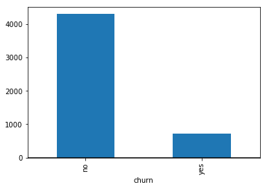

```python
gb = df.groupby(targetName)
targetEDA=gb[targetName].aggregate(len)
plt.figure()
targetEDA.plot(kind='bar', grid=False)
plt.axhline(0, color='k')
```

# Preprocessing

The below two steps are for preprocessing. The first cell changes the yes/no of the target to numeric. I needed to do this as some models require the target to be numeric. The second cell takes all the category features and creates dummies with them. This is stock code I have used for long time (and I did not write it). It is nice because it will take any dataframe of any size and handle categorial features. I do not have to change a single line in it. It can be used generically on bascially any dataframe. Saves a lot of time of coding each feature.

```python
from sklearn import preprocessing
le_dep = preprocessing.LabelEncoder()
#to convert into numbers
df['churn'] = le_dep.fit_transform(df['churn'])
```

```python
# perform data transformation
for col in df.columns[1:]:
	attName = col
	dType = df[col].dtype
	missing = pd.isnull(df[col]).any()
	uniqueCount = len(df[attName].value_counts(normalize=False))
	# discretize (create dummies)
	if dType == object:
		df = pd.concat([df, pd.get_dummies(df[col], prefix=col)], axis=1)
		del df[attName]
```

# Test/Train

I split the data into a 60/40 train test. The features are stored in "features_train" and "features_test". The targets are in "target_train" and "target_test". I used a biggest test when I have an imbalanced set.

```python
# split dataset into testing and training
features_train, features_test, target_train, target_test = train_test_split(
    df.ix[:,1:].values, df.ix[:,0].values, test_size=0.40, random_state=0)
```

Just a view of the size of each test/train set. Note there are now 73 features, and the test set is imbalanced (14.6%)

```python
print(features_test.shape)
print(features_train.shape)
print(target_test.shape)
print(target_train.shape)
print("Percent of Target that is Yes", target_test.mean())
#data.groupby(['col1', 'col2'])
```

```
(2000, 73)
(3000, 73)
(2000,)
(3000,)
Percent of Target that is Yes 0.146
```

# Models

All the models are done in Sci-Kit Learn.

# Decision Tree

```python
#Decision Tree train model
from sklearn import tree
clf = tree.DecisionTreeClassifier()
clf = clf.fit(features_train, target_train)
#DT test model
target_predicted_dt = clf.predict(features_test)
print("DT Accuracy Score", accuracy_score(target_test, target_predicted_dt))
# print classification report
target_names = ["Fail = no", "Fail = yes"]
print(classification_report(target_test, target_predicted_dt, target_names=target_names))
```

```
DT Accuracy Score 0.9265
             precision    recall  f1-score   support

  Fail = no       0.96      0.96      0.96      1708
 Fail = yes       0.75      0.74      0.75       292

avg / total       0.93      0.93      0.93      2000
```

# Cross Validation of Decision Tree

I cross validated with 10 repeats. You can see the OOB score for each repeat and the mean. The mean is .92, which is quite close to the orginal model. I am not going to worry about over fitting.

```python
#verify DT with Cross Validation
scores = cross_val_score(clf, features_train, target_train, cv=10)
print("Cross Validation Score for each K",scores)
scores.mean()
```

```
Cross Validation Score for each K [ 0.93355482  0.90697674  0.9269103   0.93687708  0.91694352  0.94314381
  0.90635452  0.93311037  0.94648829  0.90635452]
```

```
0.9256713963488481
```

# Visual of Confusion Matrix for Decision Tree

```
[[1636   72]
 [  75  217]]
```

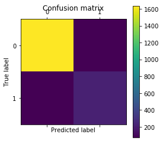

```python
# display confusion matrix
cm = confusion_matrix(target_test, target_predicted_dt)
plt.matshow(cm)
plt.title('Confusion matrix')
plt.colorbar()
plt.ylabel('True label')
plt.xlabel('Predicted label')
print(cm)
```

# Random Forest

Using the same data, I built a random forest with 500 bootstrapped trees. Notice I parallelized this to 4 cores as big random forest can be computationally expensive.

My overall results went up by 3% over the decision tree. Also, my minory target precision, but the recall decresed.

```python
# train random forest model
#paralleized to 4 cores
from sklearn.ensemble import RandomForestClassifier
rf = RandomForestClassifier(n_estimators= 500, n_jobs=-1,oob_score=True)
rf.fit(features_train, target_train)
# test random forest model
target_predicted_rf = rf.predict(features_test)
print(accuracy_score(target_test, target_predicted_rf))
target_names = ["Churn = no", "Churn = yes"]
print(classification_report(target_test, target_predicted_rf, target_names=target_names))
print(confusion_matrix(target_test, target_predicted_rf))
```

```
0.9525
             precision    recall  f1-score   support

 Churn = no       0.95      1.00      0.97      1708
Churn = yes       0.97      0.70      0.81       292

avg / total       0.95      0.95      0.95      2000

[[1701    7]
 [  88  204]]
```

# Cross Validation of Random Forest

```python
#verify RF with cross validation
scores_rf = cross_val_score(rf, features_train, target_train, cv=10, n_jobs=-1)
print("Cross Validation Score for each K",scores_rf)
scores_rf.mean()
```

```
Cross Validation Score for each K [ 0.93687708  0.94019934  0.94684385  0.95681063  0.94019934  0.95986622
  0.94983278  0.94314381  0.94648829  0.95986622]
```

```
0.94801275569728571
```

# Visual of Confusion Matrix for Random Forest

```
[[1701    7]
 [  88  204]]
```

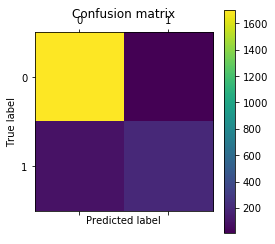

```python
# display confusion matrix
cm = confusion_matrix(target_test, target_predicted_rf)
plt.matshow(cm)
plt.title('Confusion matrix')
plt.colorbar()
plt.ylabel('True label')
plt.xlabel('Predicted label')
print(cm)
```

# Model Tuning

```python
# use a full grid over all parameters
param_grid = {"max_features": [2, 3, 4, 5]}
start_time = time.clock()




# run grid search
grid_search = GridSearchCV(rf, param_grid=param_grid,n_jobs=-1)

grid_search.fit(features_train, target_train)

print(time.clock() - start_time, "seconds")
print(grid_search.grid_scores_)
```

```
3.434462 seconds
[mean: 0.89000, std: 0.00742, params: {'max_features': 2}, mean: 0.89900, std: 0.00774, params: {'max_features': 3}, mean: 0.91700, std: 0.00921, params: {'max_features': 4}, mean: 0.92333, std: 0.00796, params: {'max_features': 5}]
```

```python
#Show importance of each feature in Random Forest
list(zip(df.columns[1:20], rf.feature_importances_))
```

```
[('account_length', 0.033346193075610639),
 ('number_vmail_messages', 0.016987830504687232),
 ('total_day_minutes', 0.12680300681969997),
 ('total_day_calls', 0.029447363952995999),
 ('total_day_charge', 0.127349235513873),
 ('total_eve_minutes', 0.05357738867827249),
 ('total_eve_calls', 0.028211341869416508),
 ('total_eve_charge', 0.05593575870792402),
 ('total_night_minutes', 0.037147940254830064),
 ('total_night_calls', 0.029332833830626546),
 ('total_night_charge', 0.037386140173686744),
 ('total_intl_minutes', 0.042238724611986848),
 ('total_intl_calls', 0.0462464814137927),
 ('total_intl_charge', 0.04217261892343125),
 ('number_customer_service_calls', 0.1005662830806381),
 ('state_AK', 0.00070764969334944315),
 ('state_AL', 0.00071648377042174969),
 ('state_AR', 0.0020908315326563457),
 ('state_AZ', 0.0020182414201330681)]
```

# ROC curve for Random Forest

Finally a ROC curve that shows the lift I get from the Random Forest model.

```
ROC AUC: 0.923
```

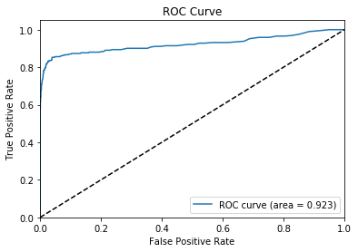

```python
# Determine the false positive and true positive rates
fpr, tpr, _ = roc_curve(target_test, rf.predict_proba(features_test)[:,1])

# Calculate the AUC
roc_auc = auc(fpr, tpr)
print('ROC AUC: %0.3f' % roc_auc)

# Plot of a ROC curve for a specific class
plt.figure()
plt.plot(fpr, tpr, label='ROC curve (area = %0.3f)' % roc_auc)
plt.plot([0, 1], [0, 1], 'k--')
plt.xlim([0.0, 1.0])
plt.ylim([0.0, 1.05])
plt.xlabel('False Positive Rate')
plt.ylabel('True Positive Rate')
plt.title('ROC Curve')
plt.legend(loc="lower right")
plt.show()
```

Random Forest does the best, but I still am not getting the accurancy on my target class of interest. I have a few tricks I can do to work on this, but that is for another day/class.